# Session 2 · Lab 1: Resampling & Only One Test

From Sampling Distribution to Bootstrap — and The Only One Test Framework

Author

Prof. Dr. Jörg Schoder

Published

today

## 1 Scenario & Orientation

In Session 1 we fitted a regression of log market value on age and found a positive coefficient. But that was **one dataset, one fit**. Would we get the same coefficient from a different season, a different sample? This lab makes uncertainty *tangible* by simulating what “repeated sampling” actually looks like — and then shows that bootstrap does the same thing from a single sample.

Along the way, we discover a unifying principle: the t-test, ANOVA, and regression are **not** separate techniques. They are all special cases of one framework.

| Phase | Name | Content | Status |
| --- | --- | --- | --- |
| 1 | Business Understanding | Identify under-/overvalued players | Done (Session 1) |
| 2 | Data Understanding | EDA of Bundesliga market values | Done (Session 1) |
| 3 | Data Preparation | log-transform, position dummy | Done (Session 1) |
| 4 | Modelling | OLS: log_value ~ age | Done (Session 1) |
| 5 | Evaluation | Is the age effect real? (inference) | ← This lab |
| 6 | Deployment | Transfer decision framework | Session 2 lecture |

**NoteLearning Objectives**

- Understand the **sampling distribution** as the foundation of all inference
- Experience the difference between a **sampling distribution** and a **bootstrap distribution** visually
- Compute **bootstrap confidence intervals** and **permutation p-values** with the `infer` package
- Recognise the “Only One Test” principle
- Understand that the common t-test or ANOVA can be viewed as regressions

**Navigation guide**

| Symbol | Box colour | Meaning | When to read |
| --- | --- | --- | --- |
| ⚠️ | Red | Mandatory task | Live session |
| 💡 | Green | Tip / best practice | Anytime |
| 📚 | Blue (collapsed) | Background theory | At home |
| ℹ️ | Blue (open) | Short clarification | When needed |

**Tip⏱ Time Budget**

**45 minutes** — complete mandatory tasks (A1–A5) first; bonus tasks if time permits.

## 2 Icebreaker: One Population, Three Stories

Three random subsamples of 30 players each from the same season produce three different regression lines.

```r
set.seed(23)
buli_s1 <- tbl_buli %>% slice_sample(n = 30)
set.seed(7)
buli_s2 <- tbl_buli %>% slice_sample(n = 30)
set.seed(42)
buli_s3 <- tbl_buli %>% slice_sample(n = 30)
```

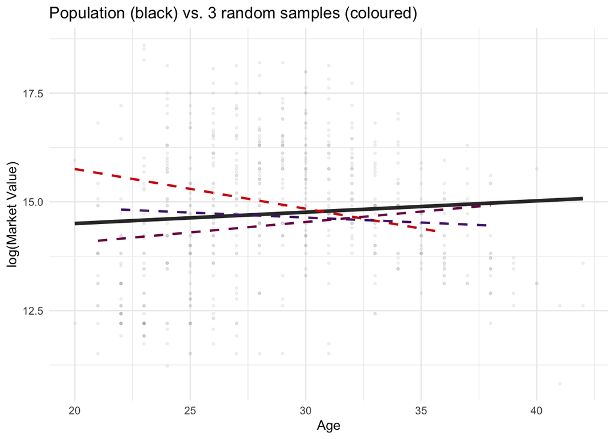

Each dashed line tells a slightly different story. Some are steeper, some flatter. If we had only seen one, we might draw a very different conclusion.

**ImportantThe Core Problem**

A single regression coefficient is **one dart thrown at a board**. To judge the thrower’s skill, we need many throws. The distribution of those throws is the **sampling distribution** — and it is the foundation of *all* statistical inference. This lab makes that distribution visible.

## 3 Step 1: The Point Estimate

Before measuring uncertainty, we need the thing we are uncertain about: the observed slope.

The `infer` package provides a pipeline that works identically for any statistic:

```
data %>% specify() %>% [hypothesize()] %>% generate() %>% calculate()
```

We start with just `specify()` + `calculate()` to get the observed value:

```r
obs_slope <- tbl_buli %>%
               specify(log_value ~ age) %>%
               calculate(stat = "slope")
obs_slope
```

```
Response: log_value (numeric)
Explanatory: age (numeric)
# A tibble: 1 × 1
    stat
   <dbl>
1 0.0261
```

This is our point estimate: $\widehat{\beta}_{\text{age}}$ = 0.0261. Because the outcome is log-transformed, the coefficient has a percentage interpretation: each additional year of age is associated with approximately $(e^{\hat\beta} - 1) \times 100$ = 2.6% higher market value.

But a single number without a measure of precision is just a guess. How much would it change if we had a different sample?

## 4 Step 2: Sampling Distribution vs. Bootstrap Distribution

This is the conceptual heart of the lab. We compare two distributions:

1. **Sampling distribution** — what happens when we draw many samples from the *population*
2. **Bootstrap distribution** — what happens when we resample from *one sample*

### 4.1 2.1 The Sampling Distribution (The Ideal We Cannot Usually See)

We treat the full Bundesliga season (≈634 players) as our population. This is a simplification — in the lecture we discussed that the season is itself one realisation of a data-generating process. But *for the purpose of understanding the sampling distribution*, we pretend these are all the players that could ever exist.

We now draw 500 random samples of n = 50, compute the slope each time, and plot the distribution:

```r
set.seed(2024)

# --- the "true" population slope ---
pop_slope <- tbl_buli %>%
               lm(log_value ~ age, data = .) %>%
               coef() %>%
               pluck("age")

# --- draw 500 samples of n=50, compute slope each time ---
sampling_dist <- map_dbl(1:500, function(i) {
  tbl_buli %>%
    slice_sample(n = 50) %>%
    lm(log_value ~ age, data = .) %>%
    coef() %>%
    pluck("age")
})
```

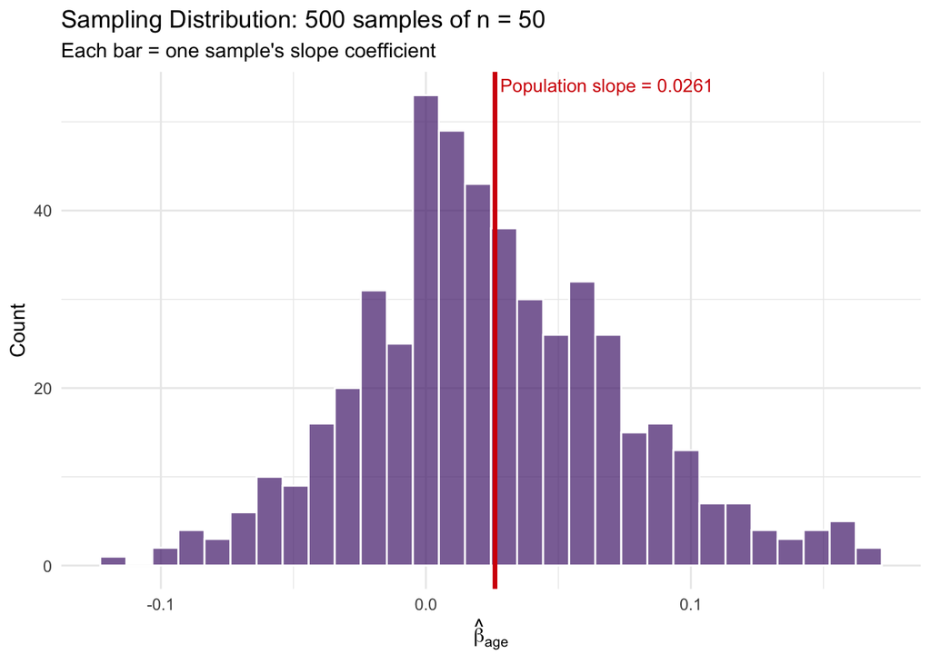

This is what we **normally never see** — the distribution of estimates across many hypothetical replications. It is centred on the “true” population slope (red line) and its spread is the **standard error**.

### 4.2 2.2 The Bootstrap Distribution (What We Can Actually Compute)

In reality we have *one* sample, not 500. Bootstrap mimics the sampling process by drawing 1,000 samples **with replacement** from that single sample:

```r
set.seed(2024)

# --- take ONE sample of n=50 ---
tbl_sample <- tbl_buli %>% slice_sample(n = 50)

# --- bootstrap: resample 1000x with replacement from that ONE sample ---
boot_dist <- tbl_sample %>%
               specify(log_value ~ age) %>%
               generate(reps = 1000, type = "bootstrap") %>%
               calculate(stat = "slope")
```

### 4.3 2.3 The Comparison — Do They Match?

Now we overlay both distributions. If bootstrap works, the two should look similar:

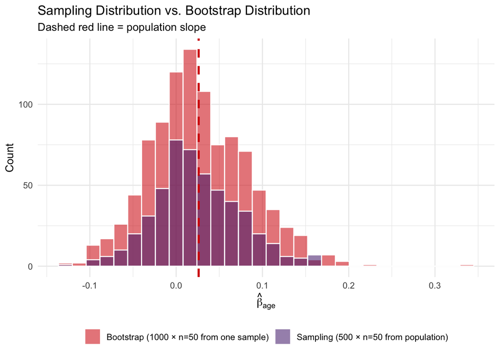

The two distributions have similar shape and spread. The bootstrap is centred on the *sample* slope (slightly off from the population slope), but the **width** — the standard error — is well approximated.

**ImportantThe Key Insight**

The **sampling distribution** shows what happens with many real samples — we normally can’t see it. The **bootstrap distribution** approximates it from a single sample. This is why bootstrap works: it estimates the *variability* of your statistic without needing repeated experiments.

**Note📚 Background: Why Does Bootstrap Work?**

The bootstrap treats the observed sample as a stand-in for the population. The central limit theorem guarantees that — for large enough samples — the bootstrap distribution converges to the true sampling distribution, regardless of the underlying data distribution. The bootstrap gets the *spread* right (standard error), even though its *centre* is the sample statistic rather than the population parameter. This is why bootstrap confidence intervals have correct coverage rates.

```r
set.seed(2024)

# --- point estimate from full data ---
obs_slope <- tbl_buli %>%
               specify(log_value ~ age) %>%
               calculate(stat = "slope")

# --- bootstrap from full data ---
boot_dist_full <- tbl_buli %>%
                    specify(log_value ~ age) %>%
                    generate(reps = 1000, type = "bootstrap") %>%
                    calculate(stat = "slope")
```

## 5 Step 3: Bootstrap Confidence Interval

The bootstrap distribution from Step 2 gives us two ways to construct a 95% confidence interval:

**Percentile Method**

Take the middle 95% of the bootstrap distribution — the simplest approach:

```r
ci_pct <- boot_dist_full %>%
            get_confidence_interval(type = "percentile", level = 0.95)
ci_pct
```

```
# A tibble: 1 × 2
   lower_ci upper_ci
      <dbl>    <dbl>
1 -0.000917   0.0531
```

**Standard Error Method**

Centre the interval around the observed estimate, using the bootstrap standard error:

```r
ci_se <- boot_dist_full %>%
           get_confidence_interval(
             type           = "se",
             point_estimate = obs_slope,
             level          = 0.95
           )
ci_se
```

```
# A tibble: 1 × 2
   lower_ci upper_ci
      <dbl>    <dbl>
1 -0.000514   0.0527
```

**Visualisation**

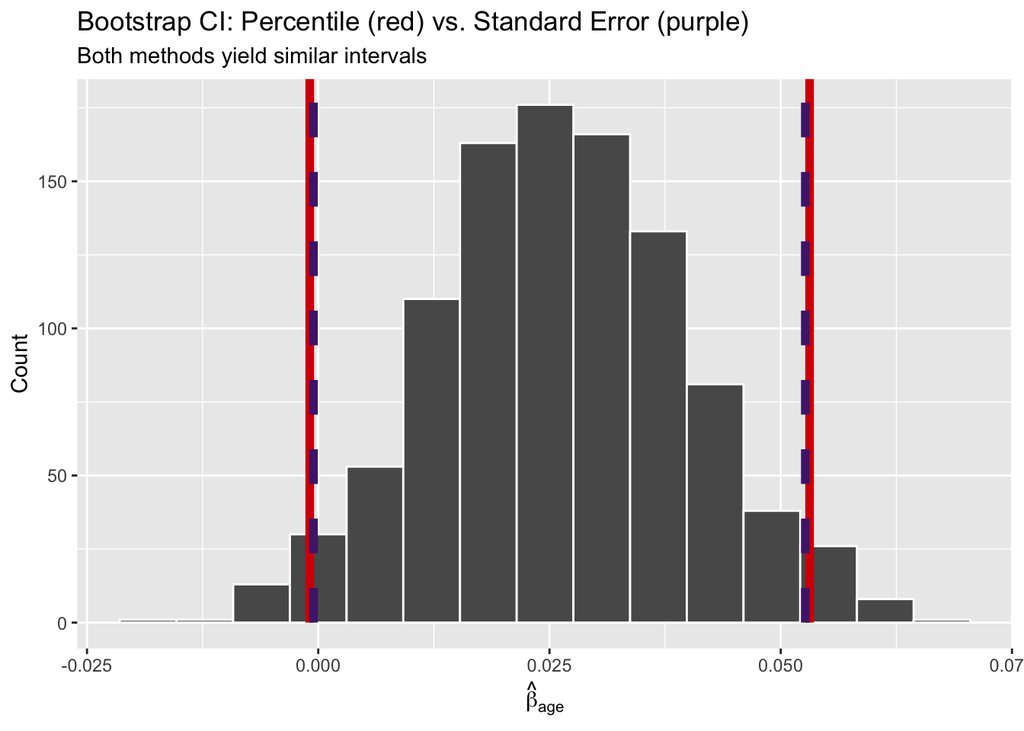

Look carefully at the lower bounds of both intervals. Do they contain zero? We will return to this question in Step 6.

**ImportantCorrect Interpretation of the CI**

Under repeated sampling, 95% of confidence intervals constructed this way would contain the true parameter $\beta_{\text{age}}$.

**Not:** “There is a 95% probability that the true value lies in this interval.”

## 6 Step 4: Permutation Test

The permutation test approaches inference from the opposite direction: instead of estimating how much the coefficient *varies*, it simulates a **world where there is no relationship at all**. By randomly shuffling the age values, any systematic association between age and market value is destroyed.

```r
set.seed(2024)

null_dist <- tbl_buli %>%
               specify(log_value ~ age) %>%
               hypothesize(null = "independence") %>%
               generate(reps = 1000, type = "permute") %>%
               calculate(stat = "slope")

p_val <- null_dist %>%
           get_p_value(obs_stat = obs_slope, direction = "two-sided")
p_val
```

```
# A tibble: 1 × 1
  p_value
    <dbl>
1   0.034
```

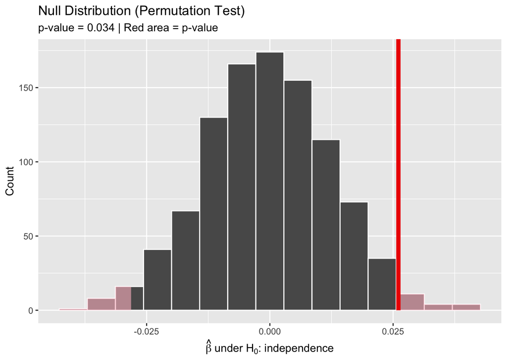

**Note📚 Background: Bootstrap vs. Permutation — When to Use Which?**

|  | **Bootstrap** | **Permutation** |
| --- | --- | --- |
| `hypothesize()` | No | Yes (`null = "independence"`) |
| `generate()` type | `"bootstrap"` | `"permute"` |
| Question | “How much does my estimate vary?” | “Could this result arise by chance?” |
| Output | Confidence interval | p-value |

Both are resampling methods, but they answer *different questions*. Bootstrap estimates variability; permutation tests a null hypothesis.

## 7 Step 5: Only One Test — Regression Subsumes Everything

In many introductory statistics courses, the t-test, ANOVA, and regression are taught as separate procedures. They are not. **They are all special cases of the linear model.**

### 7.1 5.1 The t-Test Is a Regression

Do goalkeepers and outfield players have different log market values? The classic way to test this is a two-sample t-test. But we can also frame it as a regression:

$$\log(\text{mv}) = \beta_0 + \beta_1 \cdot \mathbb{I}_{\text{Outfield}} + \varepsilon$$

Here, $\beta_1$ is the *difference in group means* — exactly what the t-test estimates.

```r
# --- approach 1: t-test ---
t_result <- t.test(log_value ~ pos_bin, data = tbl_buli, var.equal = TRUE)

# --- approach 2: regression ---
lm_pos <- lm(log_value ~ pos_bin, data = tbl_buli)
```

| Approach | Estimate | t-statistic | p-value |
| --- | --- | --- | --- |
| t-test | 1.5354 | −8.8167 | 0.0000 |
| Regression | 1.5354 | 8.8167 | 0.0000 |

The values are identical (up to sign convention for the t-statistic)

The estimates, t-statistics, and p-values are identical. **The t-test is just a regression with a binary predictor.**

**Note📚 Background: Why Are They the Same?**

The two-sample t-test with equal variances computes:

$$t = \frac{\bar{x}_1 - \bar{x}_2}{s_p \sqrt{1/n_1 + 1/n_2}}$$

The regression t-test for $\beta_1$ in $Y = \beta_0 + \beta_1 X$ with a binary $X$ computes:

$$t = \frac{\hat\beta_1}{\text{SE}(\hat\beta_1)}$$

These are algebraically identical. The regression simply uses matrix algebra to express the same quantity.

### 7.2 5.2 ANOVA Is a Regression with a Factor

What if we have more than two groups? Instead of the binary goalkeeper/outfield split, we use four position categories: Goalkeeper, Defender, Midfielder, Forward.

```r
# --- verify position groups ---
tbl_buli %>% count(pos_cat)
```

```
     pos_cat   n
1 Goalkeeper  80
2   Defender 258
3 Midfielder 122
4    Forward 174
```

```r
# --- regression with a factor (k levels) ---
lm_pos4 <- lm(log_value ~ pos_cat, data = tbl_buli)
```

| term | estimate | std_error | statistic | p_value | lower_ci | upper_ci |
| --- | --- | --- | --- | --- | --- | --- |
| intercept | 13.390 | 0.162 | 82.405 | 0.000 | 13.071 | 13.710 |
| pos_cat: Defender | 1.401 | 0.186 | 7.531 | 0.000 | 1.035 | 1.766 |
| pos_cat: Midfielder | 1.693 | 0.209 | 8.096 | 0.000 | 1.282 | 2.103 |
| pos_cat: Forward | 1.625 | 0.196 | 8.276 | 0.000 | 1.239 | 2.010 |

Yellow = significant at α = 0.05. Reference category: Goalkeeper

Each coefficient is a t-test comparing that position to the reference (Goalkeeper). But there is also a **global question**: does position matter *at all*? That is the F-test:

```r
# --- the F-test: does ANY position coefficient differ from zero? ---
anova(lm_pos4)
```

```
Analysis of Variance Table

Response: log_value
           Df  Sum Sq Mean Sq F value                Pr(>F)
pos_cat     3  173.89  57.964   27.44 < 0.00000000000000022 ***
Residuals 630 1330.79   2.112
---
Signif. codes:  0 '***' 0.001 '**' 0.01 '*' 0.05 '.' 0.1 ' ' 1
```

| r_squared | adj_r_squared | mse | rmse | sigma | statistic | p_value | df | nobs |
| --- | --- | --- | --- | --- | --- | --- | --- | --- |
| 0.116 | 0.111 | 2.099 | 1.449 | 1.453 | 27.440 | 0.000 | 3.000 | 634.000 |

The F-statistic tests: do ALL position coefficients jointly equal zero?

The t-test asks: “Is *this one* coefficient different from zero?” The F-test asks: “Is *any* coefficient different from zero?” Both live inside `get_regression_table()` and `get_regression_summaries()`.

**Note📚 Background: The Testing Hierarchy**

| Test | Question | Model |
| --- | --- | --- |
| **t-test (2 groups)** | Is the mean difference ≠ 0? | `lm(y ~ x_binary)` |
| **ANOVA (k groups)** | Is any group mean different? | `lm(y ~ x_factor)` |
| **Simple regression** | Is the slope ≠ 0? | `lm(y ~ x_numeric)` |
| **Multiple regression** | Are any slopes ≠ 0? | `lm(y ~ x1 + x2 + ...)` |

All of these are the *same* linear model $Y = X\beta + \varepsilon$, just with different design matrices $X$. This is the “Only One Test” principle from [ModernDive](https://moderndive.com): learn one framework and you can handle any hypothesis.

For a comprehensive overview of which test maps to which regression, see the flowchart in [Appendix D of ModernDive](https://moderndive.com/D-regression).

### 7.3 5.3 The Resampling Version

All of the above relies on theoretical distributions (t, F). With infer, we can replace *any* of them with a permutation test. The logic is always identical — shuffle the predictor, recompute, compare.

```r
set.seed(2024)

# --- observed F-statistic ---
obs_f <- tbl_buli %>%
           specify(log_value ~ pos_cat) %>%
           calculate(stat = "F")

# --- null distribution via permutation ---
null_f <- tbl_buli %>%
            specify(log_value ~ pos_cat) %>%
            hypothesize(null = "independence") %>%
            generate(reps = 1000, type = "permute") %>%
            calculate(stat = "F")

p_f <- null_f %>% get_p_value(obs_stat = obs_f, direction = "greater")
```

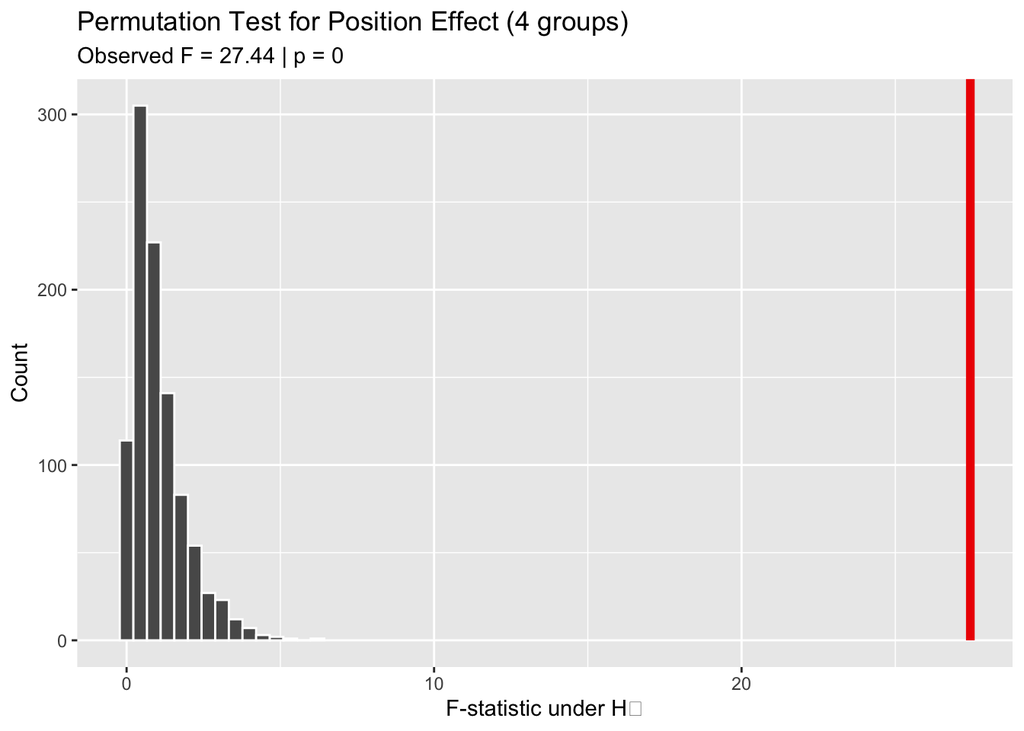

Same conclusion, no distributional assumptions required.

## 8 Step 6: Verification — Traditional Regression Output

We close the loop by showing `get_regression_table()` for the simple age model — the same numbers we computed via resampling in Steps 2–4:

```r
reg_buli <- lm(log_value ~ age, data = tbl_buli)
get_regression_table(reg_buli)
```

```
# A tibble: 2 × 7
  term      estimate std_error statistic p_value lower_ci upper_ci
  <chr>        <dbl>     <dbl>     <dbl>   <dbl>    <dbl>    <dbl>
1 intercept   14.0       0.38      36.8    0       13.2     14.7
2 age          0.026     0.013      2.00   0.045    0.001    0.052
```

| term | estimate | std_error | statistic | p_value | lower_ci | upper_ci |
| --- | --- | --- | --- | --- | --- | --- |
| intercept | 13.9810 | 0.3800 | 36.8220 | 0.0000 | 13.2350 | 14.7270 |
| age | 0.0260 | 0.0130 | 2.0050 | 0.0450 | 0.0010 | 0.0520 |

Yellow: age coefficient — compare CI with bootstrap result from Step 3

### Three Methods, One Answer?

| Method | CI Lower | CI Upper | Contains zero? |
| --- | --- | --- | --- |
| Bootstrap (Percentile) | -0.0009 | 0.0531 | Yes ⚠️ |
| Bootstrap (SE) | -0.0005 | 0.0527 | Yes ⚠️ |
| Traditional (t-test) | 0.0010 | 0.0520 | No |

Green = CI excludes zero (significant); Yellow = CI includes zero (not significant at 5%)

This is an instructive result. The three methods do **not** give the same clear-cut answer:

- The **traditional t-test CI** narrowly excludes zero — the age effect is significant at 5%.
- The **bootstrap CIs** narrowly *include* zero — by this criterion, the effect is not significant at 5%.
- The **permutation p-value** (0.034) is below 0.05 — significant.

How can bootstrap CIs include zero while the permutation test says “significant”? Because they answer **different questions**: the CI estimates a *range*, the p-value estimates a *probability*. With only 1,000 resamples, the tails of the bootstrap distribution are imprecise — and this is a borderline case where the effect sits right at the boundary.

**ImportantThe Didactic Takeaway**

When an effect is clearly large (e.g. p = 0.001), all methods agree. At the **boundary** (p ≈ 0.03–0.05), methods may diverge — not because one is “wrong,” but because the signal is genuinely weak. In such cases:

- The exact verdict (“significant” vs. “not significant”) depends on method and random seed
- The *direction* and *magnitude* of the estimate are more informative than the binary verdict
- This motivates the discussion of **effect sizes** and **practical significance** in the lecture

## 9 Mandatory Tasks

**Important⚠️ A1: Sampling vs. Bootstrap Distribution**

Look at the overlay plot from Step 2.3.

1. In what respect are the two distributions **similar**?
2. In what respect do they **differ**?
3. Why is the bootstrap distribution centred on the *sample* slope rather than the *population* slope?

**Important⚠️ A2: Confidence Interval Interpretation**

The bootstrap CI from Step 3 is [-0.0009, 0.0531].

1. Does this interval contain zero? What does that imply?
2. Write the correct interpretation of “95% confidence” in one sentence.
3. A colleague says: “There’s a 95% chance the true slope is in this interval.” Why is that wrong?

**Important⚠️ A3: Permutation Test**

The permutation p-value is 0.034.

1. In your own words: what does the null distribution in Step 4 represent?
2. Why is the null distribution centred at zero?
3. The p-value from `get_regression_table()` is 0.045. Are they consistent?
4. The permutation test says “significant” (p < 0.05), but the bootstrap CI from A2 includes zero. How can both be true at the same time? (Hint: think about what each method estimates and how 1,000 resamples affect precision in the tails.)

**Important⚠️ A4: t-Test = Regression**

Look at the comparison table in Step 5.1.

1. Which column confirms that the t-test and regression give the same result?
2. A colleague insists on using a t-test “because it’s the right test for comparing two groups.” What would you say?
3. What advantage does the regression framing have over the classical t-test framing?

**Important⚠️ A5: ANOVA & F-Test**

Look at the regression table and F-test in Step 5.2.

1. What is the reference category? How do you know?
2. Pick one of the position coefficients from the regression table. What does its sign and magnitude mean?
3. Why do we need the F-test when we already have t-tests for each coefficient?

## 10 Bonus Tasks

**Tip💡 B1: Sample Size and Bootstrap Precision**

Repeat the Step 2 comparison with n = 20 and n = 100. How does sample size affect the bootstrap’s ability to approximate the sampling distribution?

```r
set.seed(2024)
tbl_n20  <- tbl_buli %>% slice_sample(n = 20)
tbl_n100 <- tbl_buli %>% slice_sample(n = 100)
# bootstrap each and compare spread
```

**Tip💡 B2: Permutation Test for the Position Effect**

Use `infer` to run a permutation test for the binary variable `pos_bin` (Goalkeeper vs. Outfield) with `stat = "diff in means"`. Compare the p-value with the regression p-value from Step 5.1.

```r
tbl_buli %>%
  specify(log_value ~ pos_bin) %>%
  hypothesize(null = "independence") %>%
  generate(reps = 1000, type = "permute") %>%
  calculate(stat = "diff in means", order = c("Outfield", "Goalkeeper"))
```

**Tip💡 B3: ModernDive Flowchart**

Open the [hypothesis testing flowchart in ModernDive Appendix D](https://moderndive.com/D-regression). Pick two tests from the flowchart and show — using the Bundesliga data — that they are equivalent to a linear regression.

## 11 Summary

| Finding | Key Result | Implication for Lab 2 |
| --- | --- | --- |
| Sampling ≈ Bootstrap | Bootstrap approximates the sampling dist. | Justifies resampling for inference |
| Bootstrap CI vs. t-test CI | Bootstrap barely includes zero; t-test excludes it | Borderline cases reveal method differences |
| Permutation p-value | p = 0.034 (< 0.05) | Significant — but bootstrap CI disagrees |
| Boundary lesson | Binary verdict depends on method at the boundary | → effect sizes & practical significance matter |
| t-test = regression | Identical estimates, t-stats, p-values | Regression is the universal framework |
| ANOVA = regression with factor | F-test = global significance test | → multiple regression in Session 3 |

**NoteWhat Comes Next**

The age effect is borderline — the traditional t-test calls it significant, the bootstrap CI is ambiguous. In **Lab 2** we open the black box of `get_regression_table()` and connect every column (SE, t, p, CI) to its resampling counterpart using the **Stocker notation** (population vs. estimator vs. estimate). We also introduce `infer::fit()` for the interaction model and use **residual diagnostics** to decide which standard errors to trust.

**Dataset used:** `buli_raw_2023-09-06.rds` (Bundesliga players, season 2022/23)